# Practical Machine Learning

Nur Seto Dimas

9 November 2019

# **Executive Summary**

# **Overview**

> Using devices such as Jawbone Up, Nike FuelBand, and Fitbit it is now possible to collect a large amount of data about personal activity relatively inexpensively. These type of devices are part of the quantified self movement – a group of enthusiasts who take measurements about themselves regularly to improve their health, to find patterns in their behavior, or because they are tech geeks. One thing that people regularly do is quantify how much of a particular activity they do, but they rarely quantify how well they do it. In this project, your goal will be to use data from accelerometers on the belt, forearm, arm, and dumbell of 6 participants. They were asked to perform barbell lifts correctly and incorrectly in 5 different ways. More information is available from the website here: http://web.archive.org/web/20161224072740/http:/groupware.les.inf.puc-rio.br/har (see the section on the Weight Lifting Exercise Dataset).

# **Data Preparation**

```r
library(caret)
library(rpart)
library(randomForest)
library(rattle)
library(gbm)
```

```r
training_data <- read.csv("./data/pml-training.csv", header=TRUE)

validation_data <- read.csv("./data/pml-testing.csv", header = TRUE)
```

Split training_data into training and testing data then use testing in cross validation.

```r
set.seed(2019)

inTrain <- createDataPartition(training_data$classe, p = .7, list = FALSE)
training <- training_data[inTrain, ]
testing <- training_data[-inTrain, ]
```

Removing near zero variance predictors

```r
NZV <- nearZeroVar(training)
training <- training[ , -NZV]
testing <- testing[ , -NZV]
```

Removing predictors that contains mostly NA values

```r
NA_variables <- sapply(training, function(x) mean(is.na(x))) > .9
training <- training[ , NA_variables==FALSE]
testing <- testing[ , NA_variables==FALSE]
```

Removing identification predictors

```r
training <- training[ , -(1:5)]
testing <- testing[ , -(1:5)]
```

# **Model Building**

Three method will be applied to create prediction model from training data set and the most accurate model will be used to predict the quiz questions.

**a. Decision Trees**

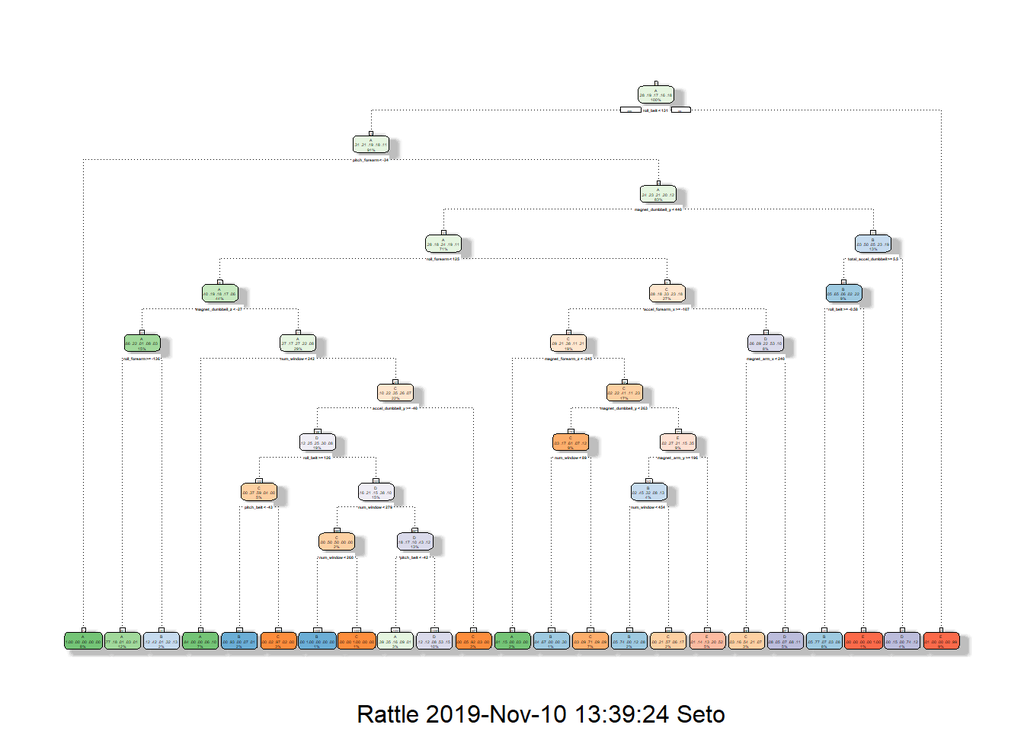

```r
set.seed(2019)
fit_decisionTree <- rpart(classe ~ ., data = training, method = "class")
fancyRpartPlot(fit_decisionTree)
```

Validating model

```r
pred_decisionTree <- predict(fit_decisionTree, testing, type = "class")
confmatx_decisionTree <- confusionMatrix(pred_decisionTree, testing$classe)
confmatx_decisionTree$overall[1]
```

```
##  Accuracy
## 0.7497026
```

```r
confmatx_decisionTree$table
```

```
##           Reference
## Prediction    A    B    C    D    E
##          A 1511  204   45   68   46
##          B   46  669   30   88  107
##          C   13   91  849   82   77
##          D   96  138   63  679  148
##          E    8   37   39   47  704
```

**b. Random Forest**

```r
set.seed(2019)
fit_RndForest <- randomForest(classe ~ ., data = training)
fit_RndForest
```

```
##
## Call:
##  randomForest(formula = classe ~ ., data = training)
##                Type of random forest: classification
##                      Number of trees: 500
## No. of variables tried at each split: 7
##
##         OOB estimate of  error rate: 0.24%
## Confusion matrix:
##      A    B    C    D    E class.error
## A 3906    0    0    0    0 0.000000000
## B    5 2652    1    0    0 0.002257336
## C    0   10 2385    1    0 0.004590985
## D    0    0   12 2240    0 0.005328597
## E    0    0    0    4 2521 0.001584158
```

Validating model

```r
pred_RndForest <- predict(fit_RndForest, testing, type = "class")
confmatx_RndForest <- confusionMatrix(pred_RndForest, testing$classe)
confmatx_RndForest$overall[1]
```

```
##  Accuracy
## 0.9974511
```

```r
confmatx_RndForest$table
```

```
##           Reference
## Prediction    A    B    C    D    E
##          A 1673    2    0    0    0
##          B    1 1135    1    0    0
##          C    0    2 1023    5    0
##          D    0    0    2  958    1
##          E    0    0    0    1 1081
```

**c. Gradient Boosting Model**

```r
set.seed(2019)
fitControl <- trainControl(method = "cv", number = 5)
fit_GBM <- train(classe ~ ., data = training, method = "gbm", verbose = FALSE,
                 trControl = fitControl)
fit_GBM
```

```
## Stochastic Gradient Boosting
##
## 13737 samples
##    53 predictor
##     5 classes: 'A', 'B', 'C', 'D', 'E'
##
## No pre-processing
## Resampling: Cross-Validated (5 fold)
## Summary of sample sizes: 10990, 10987, 10991, 10990, 10990
## Resampling results across tuning parameters:
##
##   interaction.depth  n.trees  Accuracy   Kappa
##   1                   50      0.7564967  0.6909467
##   1                  100      0.8314011  0.7865418
##   1                  150      0.8722408  0.8382957
##   2                   50      0.8826518  0.8514006
##   2                  100      0.9416892  0.9262036
##   2                  150      0.9644744  0.9550500
##   3                   50      0.9366660  0.9198345
##   3                  100      0.9728452  0.9656385
##   3                  150      0.9870415  0.9836059
##
## Tuning parameter 'shrinkage' was held constant at a value of 0.1
##
## Tuning parameter 'n.minobsinnode' was held constant at a value of 10
## Accuracy was used to select the optimal model using the largest value.
## The final values used for the model were n.trees = 150,
##  interaction.depth = 3, shrinkage = 0.1 and n.minobsinnode = 10.
```

Validating model

```r
pred_GBM <- predict(fit_GBM, testing)
confmatx_GBM <- confusionMatrix(pred_GBM, testing$classe)
confmatx_GBM$overall[1]
```

```
##  Accuracy
## 0.9860663
```

```r
confmatx_GBM$table
```

```
##           Reference
## Prediction    A    B    C    D    E
##          A 1667   13    0    0    0
##          B    4 1105   11    6   10
##          C    0   19 1014    8    0
##          D    1    2    1  948    3
##          E    2    0    0    2 1069
```

# **Prediction**

For cases prediction, Random Forest will be used for its highest accuracy among other models.

```r
pred_Test <- predict(fit_RndForest, newdata = validation_data)
pred_Test
```

```
##  1  2  3  4  5  6  7  8  9 10 11 12 13 14 15 16 17 18 19 20
##  B  A  B  A  A  E  D  B  A  A  B  C  B  A  E  E  A  B  B  B
## Levels: A B C D E
```